# 1 Background

As a statistical consultant working for a real estate investment firm, your task is to develop a model to predict the selling price of a given home in Ames, Iowa. Your employer hopes to use this information to help assess whether the asking price of a house is higher or lower than the true value of the house. If the home is undervalued, it may be a good investment for the firm.

# 2 Training Data and relevant packages

In order to better assess the quality of the model you will produce, the data have been randomly divided into three separate pieces: a training data set, a testing data set, and a validation data set. For now we will load the training data set, the others will be loaded and used later.

```r
load("ames_train.Rdata")
```

Use the code block below to load any necessary packages

```r
library(statsr)
library(dplyr)
library(BAS)
library(devtools)
```

```r
library(ggplot2)
library(forcats)
library(scales)
library(MASS)
```

## 2.1 Part 1 - Exploratory Data Analysis (EDA)

When you first get your data, it’s very tempting to immediately begin fitting models and assessing how they perform. However, before you begin modeling, it’s absolutely essential to explore the structure of the data and the relationships between the variables in the data set.

Do a detailed EDA of the ames_train data set, to learn about the structure of the data and the relationships between the variables in the data set (refer to Introduction to Probability and Data, Week 2, for a reminder about EDA if needed). Your EDA should involve creating and reviewing many plots/graphs and considering the patterns and relationships you see.

After you have explored completely, submit the three graphs/plots that you found most informative during your EDA process, and briefly explain what you learned from each (why you found each informative).

```r
head(ames_train)
```

```
## # A tibble: 6 x 81
##      PID  area  price MS.SubClass MS.Zoning Lot.Frontage Lot.Area Street Alley
##    <int> <int>  <int>       <int> <fct>            <int>    <int> <fct>  <fct>
## 1 9.09e8   856 126000          30 RL                  NA     7890 Pave   <NA>
## 2 9.05e8  1049 139500         120 RL                  42     4235 Pave   <NA>
## 3 9.11e8  1001 124900          30 C (all)             60     6060 Pave   <NA>
## 4 5.35e8  1039 114000          70 RL                  80     8146 Pave   <NA>
## 5 5.34e8  1665 227000          60 RL                  70     8400 Pave   <NA>
## 6 9.08e8  1922 198500          85 RL                  64     7301 Pave   <NA>
## # … with 72 more variables: Lot.Shape <fct>, Land.Contour <fct>,
## #   Utilities <fct>, Lot.Config <fct>, Land.Slope <fct>, Neighborhood <fct>,
## #   Condition.1 <fct>, Condition.2 <fct>, Bldg.Type <fct>, House.Style <fct>,
## #   Overall.Qual <int>, Overall.Cond <int>, Year.Built <int>,
## #   Year.Remod.Add <int>, Roof.Style <fct>, Roof.Matl <fct>,
## #   Exterior.1st <fct>, Exterior.2nd <fct>, Mas.Vnr.Type <fct>,
## #   Mas.Vnr.Area <int>, Exter.Qual <fct>, Exter.Cond <fct>, Foundation <fct>,
## #   Bsmt.Qual <fct>, Bsmt.Cond <fct>, Bsmt.Exposure <fct>,
## #   BsmtFin.Type.1 <fct>, BsmtFin.SF.1 <int>, BsmtFin.Type.2 <fct>,
## #   BsmtFin.SF.2 <int>, Bsmt.Unf.SF <int>, Total.Bsmt.SF <int>, Heating <fct>,
## #   Heating.QC <fct>, Central.Air <fct>, Electrical <fct>, X1st.Flr.SF <int>,
## #   X2nd.Flr.SF <int>, Low.Qual.Fin.SF <int>, Bsmt.Full.Bath <int>,
## #   Bsmt.Half.Bath <int>, Full.Bath <int>, Half.Bath <int>,
## #   Bedroom.AbvGr <int>, Kitchen.AbvGr <int>, Kitchen.Qual <fct>,
## #   TotRms.AbvGrd <int>, Functional <fct>, Fireplaces <int>,
## #   Fireplace.Qu <fct>, Garage.Type <fct>, Garage.Yr.Blt <int>,
## #   Garage.Finish <fct>, Garage.Cars <int>, Garage.Area <int>,
## #   Garage.Qual <fct>, Garage.Cond <fct>, Paved.Drive <fct>,
## #   Wood.Deck.SF <int>, Open.Porch.SF <int>, Enclosed.Porch <int>,
## #   X3Ssn.Porch <int>, Screen.Porch <int>, Pool.Area <int>, Pool.QC <fct>,
## #   Fence <fct>, Misc.Feature <fct>, Misc.Val <int>, Mo.Sold <int>,
## #   Yr.Sold <int>, Sale.Type <fct>, Sale.Condition <fct>
```

```r
summary(ames_train)
```

```
##       PID                 area          price         MS.SubClass
##  Min.   :5.263e+08   Min.   : 334   Min.   : 12789   Min.   : 20.00
##  1st Qu.:5.285e+08   1st Qu.:1092   1st Qu.:129762   1st Qu.: 20.00
##  Median :5.354e+08   Median :1411   Median :159467   Median : 50.00
##  Mean   :7.059e+08   Mean   :1477   Mean   :181190   Mean   : 57.15
##  3rd Qu.:9.071e+08   3rd Qu.:1743   3rd Qu.:213000   3rd Qu.: 70.00
##  Max.   :1.007e+09   Max.   :4676   Max.   :615000   Max.   :190.00
##
##    MS.Zoning    Lot.Frontage       Lot.Area       Street     Alley
##  A (agr):  0   Min.   : 21.00   Min.   :  1470   Grvl:  3   Grvl: 33
##  C (all):  9   1st Qu.: 57.00   1st Qu.:  7314   Pave:997   Pave: 34
##  FV     : 56   Median : 69.00   Median :  9317              NA's:933
##  I (all):  1   Mean   : 69.21   Mean   : 10352
##  RH     :  7   3rd Qu.: 80.00   3rd Qu.: 11650
##  RL     :772   Max.   :313.00   Max.   :215245
##  RM     :155   NA's   :167
##  Lot.Shape Land.Contour  Utilities      Lot.Config  Land.Slope  Neighborhood
##  IR1:338   Bnk: 33      AllPub:1000   Corner :173   Gtl:962    NAmes  :155
##  IR2: 30   HLS: 38      NoSeWa:   0   CulDSac: 76   Mod: 33    CollgCr: 85
##  IR3:  3   Low: 20      NoSewr:   0   FR2    : 36   Sev:  5    Somerst: 74
##  Reg:629   Lvl:909                    FR3    :  5              OldTown: 71
##                                       Inside :710              Sawyer : 61
##                                                                Edwards: 60
##                                                                (Other):494
##   Condition.1   Condition.2   Bldg.Type    House.Style   Overall.Qual
##  Norm   :875   Norm   :988   1Fam  :823   1Story :521   Min.   : 1.000
##  Feedr  : 53   Feedr  :  6   2fmCon: 20   2Story :286   1st Qu.: 5.000
##  Artery : 23   Artery :  2   Duplex: 35   1.5Fin : 98   Median : 6.000
##  RRAn   : 14   PosN   :  2   Twnhs : 38   SLvl   : 41   Mean   : 6.095
##  PosN   : 11   PosA   :  1   TwnhsE: 84   SFoyer : 36   3rd Qu.: 7.000
##  RRAe   : 11   RRNn   :  1                2.5Unf : 10   Max.   :10.000
##  (Other): 13   (Other):  0                (Other):  8
##   Overall.Cond     Year.Built   Year.Remod.Add   Roof.Style    Roof.Matl
##  Min.   :1.000   Min.   :1872   Min.   :1950   Flat   :  9   CompShg:984
##  1st Qu.:5.000   1st Qu.:1955   1st Qu.:1966   Gable  :775   Tar&Grv: 11
##  Median :5.000   Median :1975   Median :1992   Gambrel:  8   WdShake:  2
##  Mean   :5.559   Mean   :1972   Mean   :1984   Hip    :204   WdShngl:  2
##  3rd Qu.:6.000   3rd Qu.:2001   3rd Qu.:2004   Mansard:  4   Metal  :  1
##  Max.   :9.000   Max.   :2010   Max.   :2010   Shed   :  0   ClyTile:  0
##                                                              (Other):  0
```

[output cut: 81 more lines]

```
##  Min.   :  0.000   Ex  :  1   GdPrv: 43   Elev:  0     Min.   :    0.00
##  1st Qu.:  0.000   Fa  :  1   GdWo : 37   Gar2:  2     1st Qu.:    0.00
##  Median :  0.000   Gd  :  1   MnPrv:120   Othr:  1     Median :    0.00
##  Mean   :  1.463   TA  :  0   MnWw :  2   Shed: 25     Mean   :   45.81
##  3rd Qu.:  0.000   NA's:997   NA's :798   TenC:  1     3rd Qu.:    0.00
##  Max.   :800.000                          NA's:971     Max.   :15500.00
##
##     Mo.Sold          Yr.Sold       Sale.Type   Sale.Condition
##  Min.   : 1.000   Min.   :2006   WD     :863   Abnorml: 61
##  1st Qu.: 4.000   1st Qu.:2007   New    : 79   AdjLand:  2
##  Median : 6.000   Median :2008   COD    : 27   Alloca :  4
##  Mean   : 6.243   Mean   :2008   ConLD  :  7   Family : 17
##  3rd Qu.: 8.000   3rd Qu.:2009   ConLw  :  6   Normal :834
##  Max.   :12.000   Max.   :2010   Con    :  5   Partial: 82
##                                  (Other): 13
```

```r
str(ames_train)
```

```
## tibble [1,000 × 81] (S3: tbl_df/tbl/data.frame)
##  $ PID            : int [1:1000] 909176150 905476230 911128020 535377150 534177230 908128060 902135020 528228540 923426010 908186050 ...
##  $ area           : int [1:1000] 856 1049 1001 1039 1665 1922 936 1246 889 1072 ...
##  $ price          : int [1:1000] 126000 139500 124900 114000 227000 198500 93000 187687 137500 140000 ...
##  $ MS.SubClass    : int [1:1000] 30 120 30 70 60 85 20 20 20 180 ...
##  $ MS.Zoning      : Factor w/ 7 levels "A (agr)","C (all)",..: 6 6 2 6 6 6 7 6 6 7 ...
##  $ Lot.Frontage   : int [1:1000] NA 42 60 80 70 64 60 53 74 35 ...
##  $ Lot.Area       : int [1:1000] 7890 4235 6060 8146 8400 7301 6000 3710 12395 3675 ...
##  $ Street         : Factor w/ 2 levels "Grvl","Pave": 2 2 2 2 2 2 2 2 2 2 ...
##  $ Alley          : Factor w/ 2 levels "Grvl","Pave": NA NA NA NA NA NA 2 NA NA NA ...
##  $ Lot.Shape      : Factor w/ 4 levels "IR1","IR2","IR3",..: 4 4 4 4 4 4 4 4 4 4 ...
##  $ Land.Contour   : Factor w/ 4 levels "Bnk","HLS","Low",..: 4 4 4 4 4 4 1 4 4 4 ...
##  $ Utilities      : Factor w/ 3 levels "AllPub","NoSeWa",..: 1 1 1 1 1 1 1 1 1 1 ...
##  $ Lot.Config     : Factor w/ 5 levels "Corner","CulDSac",..: 1 5 5 1 5 1 5 5 1 5 ...
##  $ Land.Slope     : Factor w/ 3 levels "Gtl","Mod","Sev": 1 1 1 1 1 1 2 1 1 1 ...
```

[output cut: 67 more lines]

```r
colSums(is.na(ames_train) , na.rm = TRUE , dims = 1) # the amount of NA
```

```
##             PID            area           price     MS.SubClass       MS.Zoning
##               0               0               0               0               0
##    Lot.Frontage        Lot.Area          Street           Alley       Lot.Shape
##             167               0               0             933               0
##    Land.Contour       Utilities      Lot.Config      Land.Slope    Neighborhood
##               0               0               0               0               0
##     Condition.1     Condition.2       Bldg.Type     House.Style    Overall.Qual
##               0               0               0               0               0
##    Overall.Cond      Year.Built  Year.Remod.Add      Roof.Style       Roof.Matl
##               0               0               0               0               0
##    Exterior.1st    Exterior.2nd    Mas.Vnr.Type    Mas.Vnr.Area      Exter.Qual
##               0               0               0               7               0
##      Exter.Cond      Foundation       Bsmt.Qual       Bsmt.Cond   Bsmt.Exposure
##               0               0              21              21              21
##  BsmtFin.Type.1    BsmtFin.SF.1  BsmtFin.Type.2    BsmtFin.SF.2     Bsmt.Unf.SF
##              21               1              21               1               1
##   Total.Bsmt.SF         Heating      Heating.QC     Central.Air      Electrical
##               1               0               0               0               0
##     X1st.Flr.SF     X2nd.Flr.SF Low.Qual.Fin.SF  Bsmt.Full.Bath  Bsmt.Half.Bath
##               0               0               0               1               1
##       Full.Bath       Half.Bath   Bedroom.AbvGr   Kitchen.AbvGr    Kitchen.Qual
##               0               0               0               0               0
##   TotRms.AbvGrd      Functional      Fireplaces    Fireplace.Qu     Garage.Type
##               0               0               0             491              46
##   Garage.Yr.Blt   Garage.Finish     Garage.Cars     Garage.Area     Garage.Qual
##              48              46               1               1              47
##     Garage.Cond     Paved.Drive    Wood.Deck.SF   Open.Porch.SF  Enclosed.Porch
##              47               0               0               0               0
##     X3Ssn.Porch    Screen.Porch       Pool.Area         Pool.QC           Fence
##               0               0               0             997             798
##    Misc.Feature        Misc.Val         Mo.Sold         Yr.Sold       Sale.Type
##             971               0               0               0               0
##  Sale.Condition
##               0
```

We can first use head/summary/str function to see our dataset “ames_train”

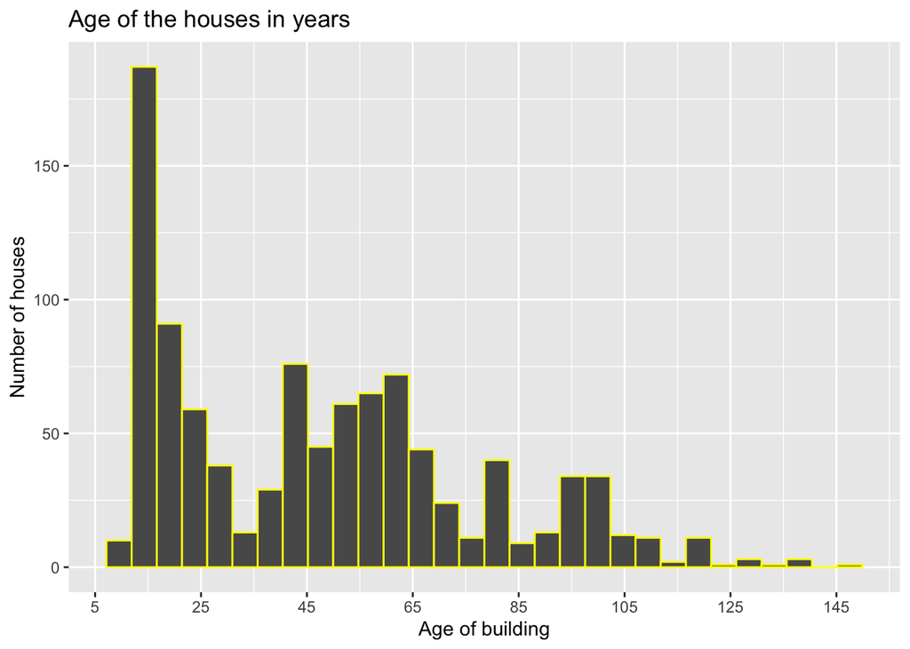

```r
ames_train <- ames_train %>%
  mutate(House.Age = 2020 - Year.Built) # 2020 because that is the current year
ggplot(data = ames_train, aes(x = House.Age)) +
  geom_histogram(bins = 30,col=c("yellow")) +
  labs(title = "Age of the houses in years", x = "Age of building", y = "Number of houses") +
  scale_x_continuous(breaks = seq(5,160,20))
```

In this diagram, we can see that the age of building for the majority of houses is between 10 and 85 years, furthermore apparently the number of houses built in approximately 10 years is the highest, reaching about 175.

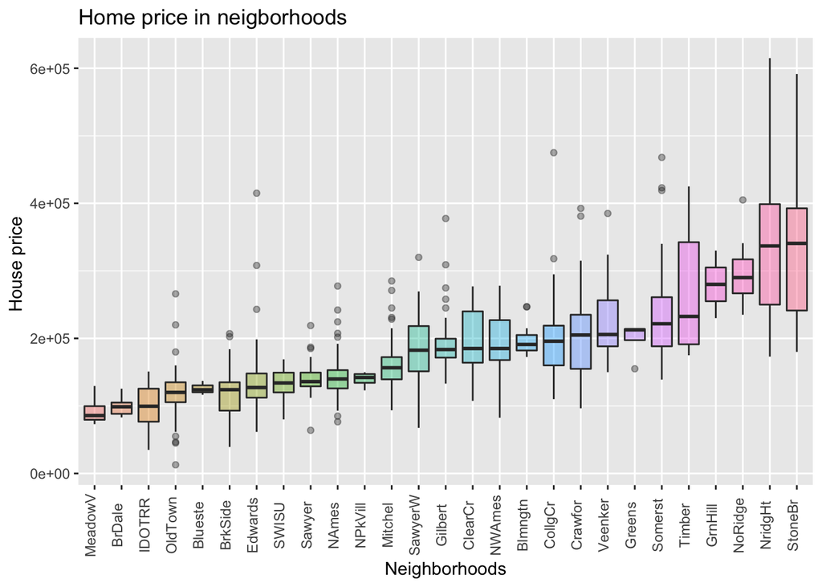

```r
ames_train %>%
  mutate(Neighborhood = fct_reorder(Neighborhood, price, .fun = "median")) %>%
ggplot(aes(x = Neighborhood, y = price, fill = Neighborhood)) +
  geom_boxplot(alpha = 0.4) +
  labs(title = "Home price in neigborhoods", x = "Neighborhoods", y = "House price ") +
  theme(axis.text.x = element_text(angle = 90, vjust = 0.1), legend.position = "none")
```

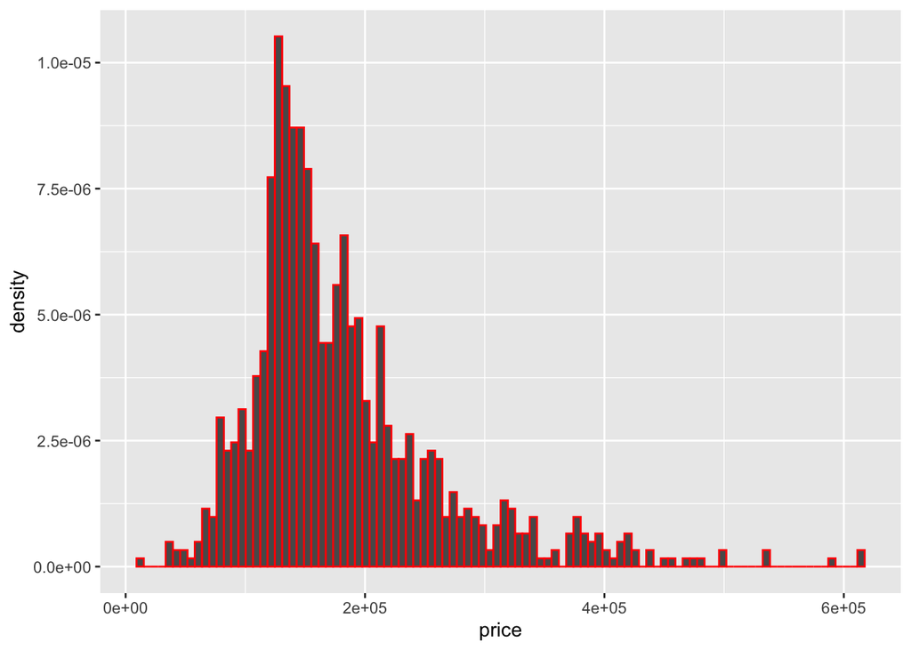

```r
ggplot(data = ames_train,mapping = aes(x = price, y=..density..))+geom_histogram(col=c("red"),bins = 100)
```

The distribution is nearly normal, slighly right skewed, and this was expected (no house can cost less than zero, but their price is theoretically limitless).There are many features that are or can be related to the variation of the prices.

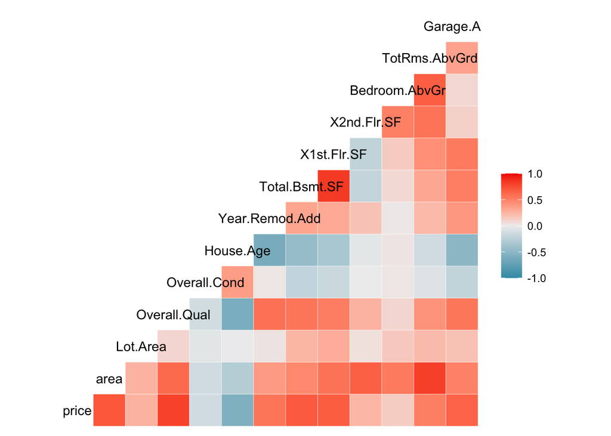

```r
library(GGally)
demo1 <- c("price","area","Lot.Area","Overall.Qual","Overall.Cond", "House.Age","Year.Remod.Add","Total.Bsmt.SF","X1st.Flr.SF","X2nd.Flr.SF","Bedroom.AbvGr","TotRms.AbvGrd","Garage.Area")
demo_new <- ames_train[demo1]
ggcorr(demo_new)
```

We can see that the correlation of all numerica variables in this plot, and we will remove these variables with pale color. We will select area,Overall.Qual,House.Age,Total.Bsmt.SF,Garage.Area

## 2.2 Part 2 - Development and assessment of an initial model, following a semi-guided process of analysis

### 2.2.1 Section 2.1 An Initial Model

In building a model, it is often useful to start by creating a simple, intuitive initial model based on the results of the exploratory data analysis. (Note: The goal at this stage is **not** to identify the “best” possible model but rather to choose a reasonable and understandable starting point. Later you will expand and revise this model to create your final model.

Based on your EDA, select *at most* 10 predictor variables from “ames_train” and create a linear model for `price` (or a transformed version of price) using those variables. Provide the *R code* and the *summary output table* for your model, a *brief justification* for the variables you have chosen, and a *brief discussion* of the model results in context (focused on the variables that appear to be important predictors and how they relate to sales price).

```r
first.model <- lm(log(price) ~ log(area) + Overall.Qual + House.Age +log(Total.Bsmt.SF +1)+log(Garage.Area + 1)+Lot.Shape+Land.Slope+Condition.1
+Bldg.Type+Sale.Condition ,data = ames_train)
summary(first.model)
```

```
##
## Call:
## lm(formula = log(price) ~ log(area) + Overall.Qual + House.Age +
##     log(Total.Bsmt.SF + 1) + log(Garage.Area + 1) + Lot.Shape +
##     Land.Slope + Condition.1 + Bldg.Type + Sale.Condition, data = ames_train)
##
## Residuals:
##      Min       1Q   Median       3Q      Max
## -1.61943 -0.08821  0.00169  0.09002  0.57031
##
## Coefficients:
##                          Estimate Std. Error t value Pr(>|t|)
## (Intercept)             7.7939365  0.1518070  51.341  < 2e-16 ***
## log(area)               0.4337792  0.0224253  19.343  < 2e-16 ***
## Overall.Qual            0.1156782  0.0063204  18.302  < 2e-16 ***
## House.Age              -0.0032763  0.0002507 -13.069  < 2e-16 ***
## log(Total.Bsmt.SF + 1)  0.0377206  0.0054716   6.894 9.77e-12 ***
## log(Garage.Area + 1)    0.0182945  0.0045980   3.979 7.44e-05 ***
## Lot.ShapeIR2            0.0491163  0.0327593   1.499  0.13412
## Lot.ShapeIR3            0.1386842  0.1024076   1.354  0.17598
## Lot.ShapeReg           -0.0164787  0.0120764  -1.365  0.17271
## Land.SlopeMod           0.1481512  0.0302062   4.905 1.10e-06 ***
## Land.SlopeSev           0.1675986  0.0800140   2.095  0.03646 *
## Condition.1Feedr        0.0619494  0.0431958   1.434  0.15185
## Condition.1Norm         0.1002859  0.0369894   2.711  0.00682 **
## Condition.1PosA         0.1483176  0.0702095   2.113  0.03490 *
## Condition.1PosN         0.0625959  0.0628875   0.995  0.31981
## Condition.1RRAe         0.0141975  0.0631048   0.225  0.82204
## Condition.1RRAn         0.0672661  0.0587851   1.144  0.25279
## Condition.1RRNe        -0.0725801  0.1247371  -0.582  0.56079
## Condition.1RRNn        -0.1041934  0.1046479  -0.996  0.31966
## Bldg.Type2fmCon        -0.0227887  0.0392603  -0.580  0.56175
## Bldg.TypeDuplex        -0.0651371  0.0321003  -2.029  0.04271 *
## Bldg.TypeTwnhs         -0.2149722  0.0288471  -7.452 2.03e-13 ***
## Bldg.TypeTwnhsE        -0.0906036  0.0204544  -4.430 1.05e-05 ***
## Sale.ConditionAdjLand   0.1420393  0.1261695   1.126  0.26054
## Sale.ConditionAlloca    0.2618893  0.1017654   2.573  0.01022 *
## Sale.ConditionFamily   -0.0900563  0.0467296  -1.927  0.05425 .
## Sale.ConditionNormal    0.1051018  0.0229657   4.576 5.34e-06 ***
## Sale.ConditionPartial   0.1568187  0.0308178   5.089 4.33e-07 ***
## ---
## Signif. codes:  0 '***' 0.001 '**' 0.01 '*' 0.05 '.' 0.1 ' ' 1
##
## Residual standard error: 0.1679 on 970 degrees of freedom
##   (2 observations deleted due to missingness)
## Multiple R-squared:  0.8448, Adjusted R-squared:  0.8405
## F-statistic: 195.6 on 27 and 970 DF,  p-value: < 2.2e-16
```

R-square value is 0.8448 and we can see that in summary table variables like “log(area)”,“Bldg.Type”,“Overall Qual”,“House age”,“Land.Slope”,“log(Total.Bsmt.SF + 1)” , “log(Garage.Area + 1)” ,“Sale.Condition” has the p-value less than 0.05. * * *

### 2.2.2 Section 2.2 Model Selection

Now either using `BAS` another stepwise selection procedure choose the “best” model you can, using your initial model as your starting point. Try at least two different model selection methods and compare their results. Do they both arrive at the same model or do they disagree? What do you think this means?

```r
model.AIC <- stepAIC(first.model, k = 2)
```

```
## Start:  AIC=-3534.23
## log(price) ~ log(area) + Overall.Qual + House.Age + log(Total.Bsmt.SF +
##     1) + log(Garage.Area + 1) + Lot.Shape + Land.Slope + Condition.1 +
##     Bldg.Type + Sale.Condition
##
##                          Df Sum of Sq    RSS     AIC
## <none>                                27.339 -3534.2
## - Lot.Shape               3    0.1923 27.532 -3533.2
## - Condition.1             8    0.5545 27.894 -3530.2
## - log(Garage.Area + 1)    1    0.4462 27.786 -3520.1
## - Land.Slope              2    0.7863 28.126 -3509.9
## - Sale.Condition          5    1.4571 28.796 -3492.4
## - log(Total.Bsmt.SF + 1)  1    1.3395 28.679 -3488.5
## - Bldg.Type               4    2.0096 29.349 -3471.4
## - House.Age               1    4.8139 32.153 -3374.4
## - Overall.Qual            1    9.4413 36.781 -3240.2
## - log(area)               1   10.5458 37.885 -3210.7
```

```r
model.AIC$anova
```

```
## Stepwise Model Path
## Analysis of Deviance Table
##
## Initial Model:
## log(price) ~ log(area) + Overall.Qual + House.Age + log(Total.Bsmt.SF +
##     1) + log(Garage.Area + 1) + Lot.Shape + Land.Slope + Condition.1 +
##     Bldg.Type + Sale.Condition
##
## Final Model:
## log(price) ~ log(area) + Overall.Qual + House.Age + log(Total.Bsmt.SF +
##     1) + log(Garage.Area + 1) + Lot.Shape + Land.Slope + Condition.1 +
##     Bldg.Type + Sale.Condition
##
##
##   Step Df Deviance Resid. Df Resid. Dev      AIC
## 1                        970   27.33938 -3534.23
```

```r
model.BIC <- stepAIC(first.model, k = log(nrow(ames_train)))
```

```
## Start:  AIC=-3396.81
## log(price) ~ log(area) + Overall.Qual + House.Age + log(Total.Bsmt.SF +
##     1) + log(Garage.Area + 1) + Lot.Shape + Land.Slope + Condition.1 +
##     Bldg.Type + Sale.Condition
##
##                          Df Sum of Sq    RSS     AIC
## - Condition.1             8    0.5545 27.894 -3432.0
## - Lot.Shape               3    0.1923 27.532 -3410.5
## <none>                                27.339 -3396.8
## - log(Garage.Area + 1)    1    0.4462 27.786 -3387.6
## - Land.Slope              2    0.7863 28.126 -3382.3
## - Sale.Condition          5    1.4571 28.796 -3379.5
## - log(Total.Bsmt.SF + 1)  1    1.3395 28.679 -3356.0
## - Bldg.Type               4    2.0096 29.349 -3353.7
## - House.Age               1    4.8139 32.153 -3241.9
## - Overall.Qual            1    9.4413 36.781 -3107.7
## - log(area)               1   10.5458 37.885 -3078.1
##
## Step:  AIC=-3432.04
## log(price) ~ log(area) + Overall.Qual + House.Age + log(Total.Bsmt.SF +
##     1) + log(Garage.Area + 1) + Lot.Shape + Land.Slope + Bldg.Type +
##     Sale.Condition
##
##                          Df Sum of Sq    RSS     AIC
## - Lot.Shape               3    0.1827 28.077 -3446.2
## <none>                                27.894 -3432.0
## - log(Garage.Area + 1)    1    0.5160 28.410 -3420.7
## - Land.Slope              2    0.8662 28.760 -3415.3
## - Sale.Condition          5    1.5181 29.412 -3413.7
## - Bldg.Type               4    1.8999 29.794 -3393.9
## - log(Total.Bsmt.SF + 1)  1    1.3754 29.269 -3390.9
## - House.Age               1    5.2654 33.159 -3266.4
## - Overall.Qual            1    9.3625 37.256 -3150.1
## - log(area)               1   10.7130 38.607 -3114.6
##
## Step:  AIC=-3446.24
## log(price) ~ log(area) + Overall.Qual + House.Age + log(Total.Bsmt.SF +
##     1) + log(Garage.Area + 1) + Land.Slope + Bldg.Type + Sale.Condition
##
##                          Df Sum of Sq    RSS     AIC
## <none>                                28.077 -3446.2
## - log(Garage.Area + 1)    1    0.5284 28.605 -3434.5
## - Sale.Condition          5    1.5674 29.644 -3426.6
## - Land.Slope              2    1.0112 29.088 -3424.7
## - log(Total.Bsmt.SF + 1)  1    1.4143 29.491 -3404.1
## - Bldg.Type               4    2.0575 30.134 -3403.3
## - House.Age               1    5.6364 33.713 -3270.6
## - Overall.Qual            1    9.4049 37.481 -3164.8
## - log(area)               1   11.0409 39.118 -3122.2
```

```r
model.BIC
```

```
##
## Call:
## lm(formula = log(price) ~ log(area) + Overall.Qual + House.Age +
##     log(Total.Bsmt.SF + 1) + log(Garage.Area + 1) + Land.Slope +
##     Bldg.Type + Sale.Condition, data = ames_train)
##
## Coefficients:
##            (Intercept)               log(area)            Overall.Qual
##               7.833129                0.439008                0.114897
##              House.Age  log(Total.Bsmt.SF + 1)    log(Garage.Area + 1)
##              -0.003448                0.038626                0.019645
##          Land.SlopeMod           Land.SlopeSev         Bldg.Type2fmCon
##               0.156377                0.230975               -0.033537
##        Bldg.TypeDuplex          Bldg.TypeTwnhs         Bldg.TypeTwnhsE
##              -0.074066               -0.215607               -0.085058
##  Sale.ConditionAdjLand    Sale.ConditionAlloca    Sale.ConditionFamily
##               0.175341                0.263343               -0.086561
##   Sale.ConditionNormal   Sale.ConditionPartial
##               0.112202                0.161861
```

### 2.2.3 Section 2.3 Initial Model Residuals

One way to assess the performance of a model is to examine the model’s residuals. In the space below, create a residual plot for your preferred model from above and use it to assess whether your model appears to fit the data well. Comment on any interesting structure in the residual plot (trend, outliers, etc.) and briefly discuss potential implications it may have for your model and inference / prediction you might produce.

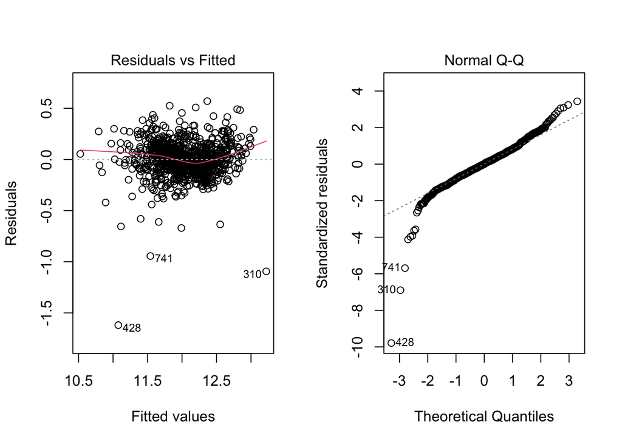

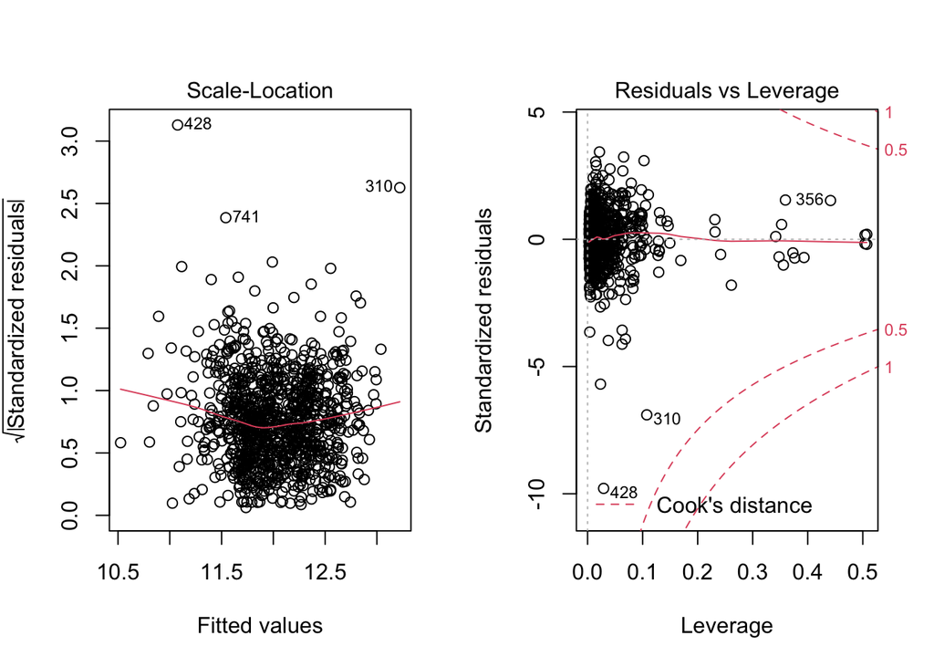

```r
par(mfrow = c(1,2))
plot(model.AIC)
```

Looking at the residual scatterplot, it seems that the residuals are distributed randomly and the are scattered around 0 horizontal line. There is also a somewhat constant variability in the plot. We do have some outliers(428,741,310) that are away from the cloud of the data. * * *

### 2.2.4 Section 2.4 Initial Model RMSE

You can calculate it directly based on the model output. Be specific about the units of your RMSE (depending on whether you transformed your response variable). The value you report will be more meaningful if it is in the original units (dollars).

```r
# Firstly, we have to remove missing vlaues.
ames_train <- ames_train%>%
  filter(!is.na(area),!is.na(Total.Bsmt.SF),!is.na(Overall.Qual),!is.na(House.Age),!is.na(Sale.Condition),!is.na(Garage.Area),!is.na(Lot.Shape),!is.na(Condition.1),!is.na(Bldg.Type),!is.na(Land.Slope))
predict.AIC <- exp(predict(model.AIC, ames_train))
resid.AIC <- ames_train$price - predict.AIC
rmse.AIC <- sqrt(mean(resid.AIC^2))
rmse.AIC
```

```
## [1] 33472.23
```

We can see that the RMSE value for model.AIC is 33472 dollars * * *

### 2.2.5 Section 2.5 Overfitting

The process of building a model generally involves starting with an initial model (as you have done above), identifying its shortcomings, and adapting the model accordingly. This process may be repeated several times until the model fits the data reasonably well. However, the model may do well on training data but perform poorly out-of-sample (meaning, on a dataset other than the original training data) because the model is overly-tuned to specifically fit the training data. This is called “overfitting.” To determine whether overfitting is occurring on a model, compare the performance of a model on both in-sample and out-of-sample data sets. To look at performance of your initial model on out-of-sample data, you will use the data set `ames_test`.

```r
load("ames_test.Rdata")
```

Use your model from above to generate predictions for the housing prices in the test data set. Are the predictions significantly more accurate (compared to the actual sales prices) for the training data than the test data? Why or why not? Briefly explain how you determined that (what steps or processes did you use)?

```r
# Because I add a variable in "ames_train" data and model. So I am going to add the same variable in "ames_test"
 ames_test<-ames_test%>%
  mutate(House.Age = 2020 - Year.Built)
  predict.AIC <- exp(predict(model.AIC, ames_test))
resid.AIC <- ames_train$price - predict.AIC
rmse.AIC <- sqrt(mean(resid.AIC^2))
rmse.AIC
```

```
## [1] 105058.6
```

**Note to the learner:** If in real-life practice this out-of-sample analysis shows evidence that the training data fits your model a lot better than the test data, it is probably a good idea to go back and revise the model (usually by simplifying the model) to reduce this overfitting. For simplicity, we do not ask you to do this on the assignment, however.

## 2.3 Part 3 Development of a Final Model

Now that you have developed an initial model to use as a baseline, create a final model with *at most* 20 variables to predict housing prices in Ames, IA, selecting from the full array of variables in the dataset and using any of the tools that we introduced in this specialization.

Carefully document the process that you used to come up with your final model, so that you can answer the questions below.

### 2.3.1 Section 3.1 Final Model

Provide the summary table for your model.

```r
final_model <- lm(log(price) ~ log(area) + Overall.Qual + House.Age +log(Total.Bsmt.SF +1)+log(Garage.Area + 1)+Lot.Shape+Land.Slope+Condition.1+Bldg.Type+Sale.Condition+Neighborhood ,data = ames_train)
final_model1 <- stepAIC(final_model,k=2)
```

```
## Start:  AIC=-3672.69
## log(price) ~ log(area) + Overall.Qual + House.Age + log(Total.Bsmt.SF +
##     1) + log(Garage.Area + 1) + Lot.Shape + Land.Slope + Condition.1 +
##     Bldg.Type + Sale.Condition + Neighborhood
##
##                          Df Sum of Sq    RSS     AIC
## <none>                                22.589 -3672.7
## - Condition.1             8    0.4276 23.017 -3670.0
## - Lot.Shape               3    0.2655 22.855 -3667.0
## - log(Garage.Area + 1)    1    0.1911 22.781 -3666.3
## - Land.Slope              2    0.2465 22.836 -3665.9
## - Sale.Condition          5    1.1916 23.781 -3631.4
## - Bldg.Type               4    1.3418 23.931 -3623.1
## - log(Total.Bsmt.SF + 1)  1    1.2438 23.833 -3621.2
## - House.Age               1    1.3593 23.949 -3616.4
## - Neighborhood           26    4.7500 27.339 -3534.2
## - Overall.Qual            1    4.7503 27.340 -3484.2
## - log(area)               1    9.1079 31.697 -3336.6
```

```r
final_model1
```

```
##
## Call:
## lm(formula = log(price) ~ log(area) + Overall.Qual + House.Age +
##     log(Total.Bsmt.SF + 1) + log(Garage.Area + 1) + Lot.Shape +
##     Land.Slope + Condition.1 + Bldg.Type + Sale.Condition + Neighborhood,
##     data = ames_train)
##
## Coefficients:
##            (Intercept)               log(area)            Overall.Qual
##               8.008529                0.432478                0.093016
##              House.Age  log(Total.Bsmt.SF + 1)    log(Garage.Area + 1)
##              -0.003038                0.037375                0.012534
##           Lot.ShapeIR2            Lot.ShapeIR3            Lot.ShapeReg
##               0.079767                0.216273                0.004130
##          Land.SlopeMod           Land.SlopeSev        Condition.1Feedr
##               0.090114                0.084820                0.002276
##        Condition.1Norm         Condition.1PosA         Condition.1PosN
##               0.069532                0.124766                0.050810
##        Condition.1RRAe         Condition.1RRAn         Condition.1RRNe
##              -0.004869                0.057843                0.026964
##        Condition.1RRNn         Bldg.Type2fmCon         Bldg.TypeDuplex
##              -0.091370               -0.005160               -0.085776
##         Bldg.TypeTwnhs         Bldg.TypeTwnhsE   Sale.ConditionAdjLand
##              -0.212178               -0.126286                0.185731
##   Sale.ConditionAlloca    Sale.ConditionFamily    Sale.ConditionNormal
##               0.303272               -0.075858                0.099071
##  Sale.ConditionPartial     NeighborhoodBlueste      NeighborhoodBrDale
##               0.135612               -0.033642               -0.150698
##    NeighborhoodBrkSide     NeighborhoodClearCr     NeighborhoodCollgCr
##              -0.029922                0.045921               -0.047241
##    NeighborhoodCrawfor     NeighborhoodEdwards     NeighborhoodGilbert
##               0.116857               -0.083410               -0.085849
##     NeighborhoodGreens     NeighborhoodGrnHill      NeighborhoodIDOTRR
##               0.166476                0.569947               -0.194698
##    NeighborhoodMeadowV     NeighborhoodMitchel       NeighborhoodNAmes
##              -0.137806                0.005390               -0.009475
##    NeighborhoodNoRidge     NeighborhoodNPkVill     NeighborhoodNridgHt
##               0.065522               -0.009823                0.158097
##     NeighborhoodNWAmes     NeighborhoodOldTown      NeighborhoodSawyer
##              -0.039716               -0.099365                0.008114
##    NeighborhoodSawyerW     NeighborhoodSomerst     NeighborhoodStoneBr
##              -0.061378                0.030157                0.176405
##      NeighborhoodSWISU      NeighborhoodTimber     NeighborhoodVeenker
##              -0.111452                0.063574                0.088892
```

```r
summary(final_model)
```

```
##
## Call:
## lm(formula = log(price) ~ log(area) + Overall.Qual + House.Age +
##     log(Total.Bsmt.SF + 1) + log(Garage.Area + 1) + Lot.Shape +
##     Land.Slope + Condition.1 + Bldg.Type + Sale.Condition + Neighborhood,
##     data = ames_train)
##
## Residuals:
##      Min       1Q   Median       3Q      Max
## -1.65293 -0.07669  0.00305  0.07969  0.62306
##
## Coefficients:
##                          Estimate Std. Error t value Pr(>|t|)
## (Intercept)             8.0085288  0.1618575  49.479  < 2e-16 ***
## log(area)               0.4324776  0.0221677  19.509  < 2e-16 ***
## Overall.Qual            0.0930165  0.0066019  14.089  < 2e-16 ***
## House.Age              -0.0030380  0.0004031  -7.537 1.13e-13 ***
## log(Total.Bsmt.SF + 1)  0.0373754  0.0051840   7.210 1.15e-12 ***
## log(Garage.Area + 1)    0.0125336  0.0044351   2.826  0.00481 **
## Lot.ShapeIR2            0.0797666  0.0310838   2.566  0.01044 *
## Lot.ShapeIR3            0.2162731  0.0960843   2.251  0.02462 *
## Lot.ShapeReg            0.0041296  0.0117812   0.351  0.72602
## Land.SlopeMod           0.0901145  0.0290542   3.102  0.00198 **
## Land.SlopeSev           0.0848196  0.0796180   1.065  0.28700
## Condition.1Feedr        0.0022758  0.0413342   0.055  0.95610
## Condition.1Norm         0.0695319  0.0347303   2.002  0.04556 *
## Condition.1PosA         0.1247660  0.0662417   1.883  0.05994 .
## Condition.1PosN         0.0508098  0.0591311   0.859  0.39041
## Condition.1RRAe        -0.0048687  0.0601655  -0.081  0.93552
## Condition.1RRAn         0.0578432  0.0557804   1.037  0.30001
## Condition.1RRNe         0.0269642  0.1163626   0.232  0.81680
## Condition.1RRNn        -0.0913695  0.0974272  -0.938  0.34857
## Bldg.Type2fmCon        -0.0051596  0.0370360  -0.139  0.88923
## Bldg.TypeDuplex        -0.0857761  0.0302004  -2.840  0.00461 **
## Bldg.TypeTwnhs         -0.2121775  0.0359674  -5.899 5.09e-09 ***
## Bldg.TypeTwnhsE        -0.1262860  0.0231182  -5.463 6.00e-08 ***
## Sale.ConditionAdjLand   0.1857308  0.1186400   1.565  0.11780
## Sale.ConditionAlloca    0.3032723  0.0944904   3.210  0.00137 **
## Sale.ConditionFamily   -0.0758576  0.0438684  -1.729  0.08410 .
## Sale.ConditionNormal    0.0990709  0.0213657   4.637 4.03e-06 ***
```

[output cut: 18 more lines]

```
## NeighborhoodNWAmes     -0.0397164  0.0579599  -0.685  0.49336
## NeighborhoodOldTown    -0.0993650  0.0624303  -1.592  0.11181
## NeighborhoodSawyer      0.0081141  0.0576473   0.141  0.88809
## NeighborhoodSawyerW    -0.0613783  0.0559811  -1.096  0.27318
## NeighborhoodSomerst     0.0301565  0.0516765   0.584  0.55965
## NeighborhoodStoneBr     0.1764051  0.0600005   2.940  0.00336 **
## NeighborhoodSWISU      -0.1114519  0.0734073  -1.518  0.12928
## NeighborhoodTimber      0.0635736  0.0629948   1.009  0.31314
## NeighborhoodVeenker     0.0888920  0.0706480   1.258  0.20862
## ---
## Signif. codes:  0 '***' 0.001 '**' 0.01 '*' 0.05 '.' 0.1 ' ' 1
##
## Residual standard error: 0.1547 on 944 degrees of freedom
## Multiple R-squared:  0.8718, Adjusted R-squared:  0.8646
## F-statistic: 121.1 on 53 and 944 DF,  p-value: < 2.2e-16
```

### 2.3.2 Section 3.2 Transformation

Did you decide to transform any variables? Why or why not? Explain in a few sentences.

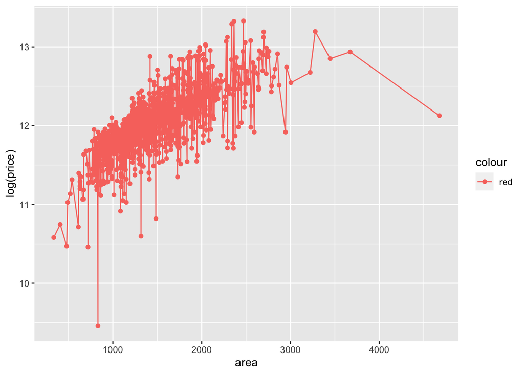

```r
ggplot(data=ames_train, aes(x=area , y=log(price),colour = "red")) +geom_point()+geom_line()
```

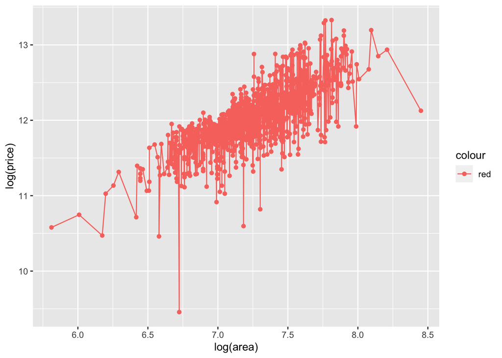

```r
ggplot(data=ames_train, aes(x=log(area) , y=log(price),colour = "red"))+geom_point()+geom_line()
```

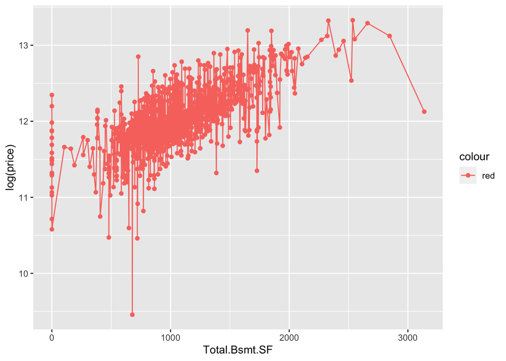

```r
ggplot(data=ames_train, aes(x=Total.Bsmt.SF , y=log(price),colour = "red"))+geom_point()+geom_line()
```

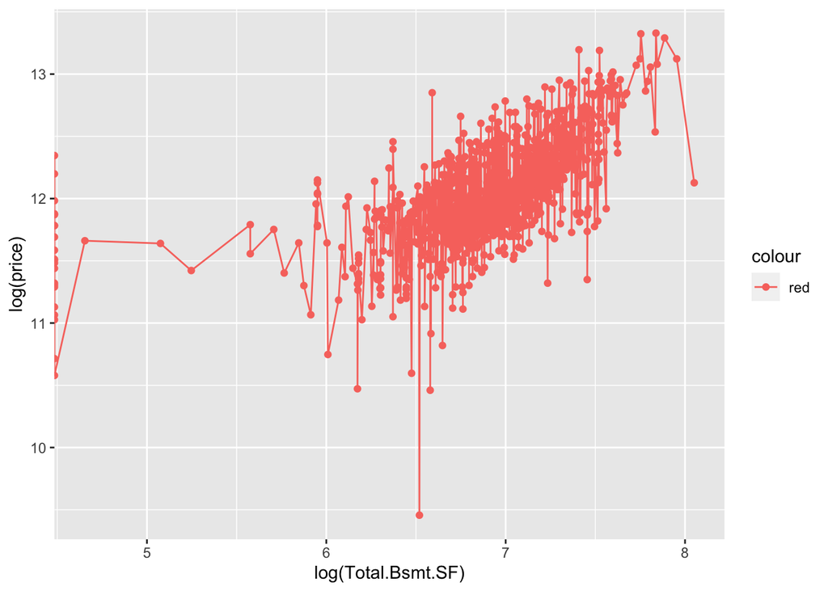

```r
ggplot(data=ames_train, aes(x=log(Total.Bsmt.SF) , y=log(price),colour = "red"))+geom_point()+geom_line()
```

### 2.3.3 Section 3.3 Variable Interaction

Did you decide to include any variable interactions? Why or why not? Explain in a few sentences.

### 2.3.4 Section 3.4 Variable Selection

What method did you use to select the variables you included? Why did you select the method you used? Explain in a few sentences.

```r
model.AIC <- stepAIC(first.model, k = 2)
```

```
## Start:  AIC=-3534.23
## log(price) ~ log(area) + Overall.Qual + House.Age + log(Total.Bsmt.SF +
##     1) + log(Garage.Area + 1) + Lot.Shape + Land.Slope + Condition.1 +
##     Bldg.Type + Sale.Condition
##
##                          Df Sum of Sq    RSS     AIC
## <none>                                27.339 -3534.2
## - Lot.Shape               3    0.1923 27.532 -3533.2
## - Condition.1             8    0.5545 27.894 -3530.2
## - log(Garage.Area + 1)    1    0.4462 27.786 -3520.1
## - Land.Slope              2    0.7863 28.126 -3509.9
## - Sale.Condition          5    1.4571 28.796 -3492.4
## - log(Total.Bsmt.SF + 1)  1    1.3395 28.679 -3488.5
## - Bldg.Type               4    2.0096 29.349 -3471.4
## - House.Age               1    4.8139 32.153 -3374.4
## - Overall.Qual            1    9.4413 36.781 -3240.2
## - log(area)               1   10.5458 37.885 -3210.7
```

```r
model.AIC$anova
```

```
## Stepwise Model Path
## Analysis of Deviance Table
##
## Initial Model:
## log(price) ~ log(area) + Overall.Qual + House.Age + log(Total.Bsmt.SF +
##     1) + log(Garage.Area + 1) + Lot.Shape + Land.Slope + Condition.1 +
##     Bldg.Type + Sale.Condition
##
## Final Model:
## log(price) ~ log(area) + Overall.Qual + House.Age + log(Total.Bsmt.SF +
##     1) + log(Garage.Area + 1) + Lot.Shape + Land.Slope + Condition.1 +
##     Bldg.Type + Sale.Condition
##
##
##   Step Df Deviance Resid. Df Resid. Dev      AIC
## 1                        970   27.33938 -3534.23
```

```r
model.BIC <- stepAIC(first.model, k = log(nrow(ames_train)))
```

```
## Start:  AIC=-3396.87
## log(price) ~ log(area) + Overall.Qual + House.Age + log(Total.Bsmt.SF +
##     1) + log(Garage.Area + 1) + Lot.Shape + Land.Slope + Condition.1 +
##     Bldg.Type + Sale.Condition
##
##                          Df Sum of Sq    RSS     AIC
## - Condition.1             8    0.5545 27.894 -3432.1
## - Lot.Shape               3    0.1923 27.532 -3410.6
## <none>                                27.339 -3396.9
## - log(Garage.Area + 1)    1    0.4462 27.786 -3387.6
## - Land.Slope              2    0.7863 28.126 -3382.4
## - Sale.Condition          5    1.4571 28.796 -3379.6
## - log(Total.Bsmt.SF + 1)  1    1.3395 28.679 -3356.0
## - Bldg.Type               4    2.0096 29.349 -3353.7
## - House.Age               1    4.8139 32.153 -3241.9
## - Overall.Qual            1    9.4413 36.781 -3107.7
## - log(area)               1   10.5458 37.885 -3078.2
##
## Step:  AIC=-3432.08
## log(price) ~ log(area) + Overall.Qual + House.Age + log(Total.Bsmt.SF +
##     1) + log(Garage.Area + 1) + Lot.Shape + Land.Slope + Bldg.Type +
##     Sale.Condition
##
##                          Df Sum of Sq    RSS     AIC
## - Lot.Shape               3    0.1827 28.077 -3446.3
## <none>                                27.894 -3432.1
## - log(Garage.Area + 1)    1    0.5160 28.410 -3420.7
## - Land.Slope              2    0.8662 28.760 -3415.4
## - Sale.Condition          5    1.5181 29.412 -3413.7
## - Bldg.Type               4    1.8999 29.794 -3393.9
## - log(Total.Bsmt.SF + 1)  1    1.3754 29.269 -3390.9
## - House.Age               1    5.2654 33.159 -3266.4
## - Overall.Qual            1    9.3625 37.256 -3150.1
## - log(area)               1   10.7130 38.607 -3114.6
##
## Step:  AIC=-3446.28
## log(price) ~ log(area) + Overall.Qual + House.Age + log(Total.Bsmt.SF +
##     1) + log(Garage.Area + 1) + Land.Slope + Bldg.Type + Sale.Condition
##
##                          Df Sum of Sq    RSS     AIC
## <none>                                28.077 -3446.3
## - log(Garage.Area + 1)    1    0.5284 28.605 -3434.6
## - Sale.Condition          5    1.5674 29.644 -3426.6
## - Land.Slope              2    1.0112 29.088 -3424.8
## - log(Total.Bsmt.SF + 1)  1    1.4143 29.491 -3404.1
## - Bldg.Type               4    2.0575 30.134 -3403.3
## - House.Age               1    5.6364 33.713 -3270.6
## - Overall.Qual            1    9.4049 37.481 -3164.9
## - log(area)               1   11.0409 39.118 -3122.2
```

```r
model.BIC
```

```
##
## Call:
## lm(formula = log(price) ~ log(area) + Overall.Qual + House.Age +
##     log(Total.Bsmt.SF + 1) + log(Garage.Area + 1) + Land.Slope +
##     Bldg.Type + Sale.Condition, data = ames_train)
##
## Coefficients:
##            (Intercept)               log(area)            Overall.Qual
##               7.833129                0.439008                0.114897
##              House.Age  log(Total.Bsmt.SF + 1)    log(Garage.Area + 1)
##              -0.003448                0.038626                0.019645
##          Land.SlopeMod           Land.SlopeSev         Bldg.Type2fmCon
##               0.156377                0.230975               -0.033537
##        Bldg.TypeDuplex          Bldg.TypeTwnhs         Bldg.TypeTwnhsE
##              -0.074066               -0.215607               -0.085058
##  Sale.ConditionAdjLand    Sale.ConditionAlloca    Sale.ConditionFamily
##               0.175341                0.263343               -0.086561
##   Sale.ConditionNormal   Sale.ConditionPartial
##               0.112202                0.161861
```

### 2.3.5 Section 3.5 Model Testing

How did testing the model on out-of-sample data affect whether or how you changed your model? Explain in a few sentences.

## 2.4 Part 4 Final Model Assessment

### 2.4.1 Section 4.1 Final Model Residual

For your final model, create and briefly interpret an informative plot of the residuals.

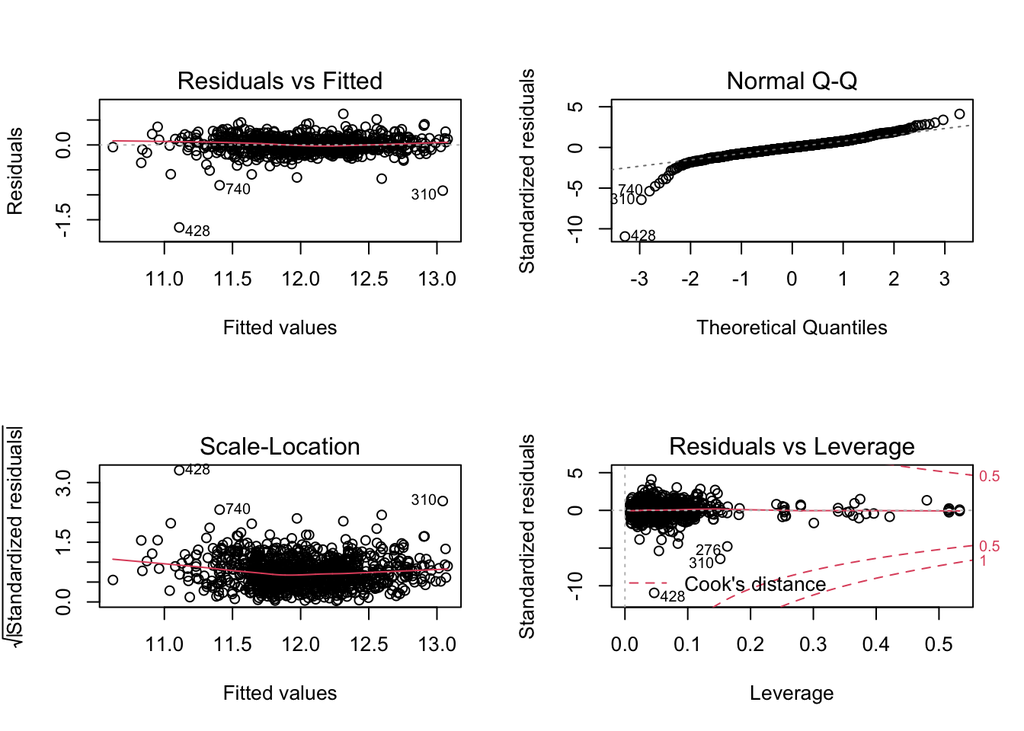

```r
par(mfrow = c(2,2))
plot(final_model)
```

The 1st plot is the Residuals vs Fitted plot. It shows if Residuals have linear arrangement. This plot indicate a good fit for a linear model.

The 2nd plot is the Normal Q-Q plot. It illustrates if residuals are normally distributed. In this case, the residuals are normally distributed in two standard deviations range.

The 3rd plot is called Scale-Location (or Spread-Location) plot. It illustrates if residuals are spread equally along the ranges of predictors. In this case, Residuals appear randomly spread.

The 4th plot is the Residuals vs Leverage plot. It should help us to find influential cases.

### 2.4.2 Section 4.2 Final Model RMSE

For your final model, calculate and briefly comment on the RMSE.

```r
predict.final.AIC <- exp(predict(final_model1, ames_train))
resid.final.AIC <- ames_train$price - predict.final.AIC
rmse.final.AIC <- sqrt(mean(resid.final.AIC^2))
rmse.final.AIC
```

```
## [1] 29457.81
```

### 2.4.3 Section 4.3 Final Model Evaluation

What are some strengths and weaknesses of your model?

Advantages: I think my model do not have many predicators, it is simple. It is convenient for others to use. Disadvantages: I think there was not clear involved for the variables selection, in EDA, we do not have a very explicit standard to guide how to choose variables.

### 2.4.4 Section 4.4 Final Model Validation

Testing your final model on a separate, validation data set is a great way to determine how your model will perform in real-life practice.

You will use the “ames_validation” dataset to do some additional assessment of your final model. Discuss your findings, be sure to mention: * What is the RMSE of your final model when applied to the validation data?  
* How does this value compare to that of the training data and/or testing data? * What percentage of the 95% predictive confidence (or credible) intervals contain the true price of the house in the validation data set?  
* From this result, does your final model properly reflect uncertainty?

```r
load("ames_validation.Rdata")
```

```r
# Because I add a variable in "ames_train" data and model. So I am going to add the same variable in "ames_validation"
 ames_validation<-ames_validation%>%
  mutate(House.Age = 2020 - Year.Built)
predict_final_AIC <- exp(predict(final_model1, ames_validation))
resid_final_AIC <- ames_test$price - predict_final_AIC
rmse_final_AIC <- sqrt(mean(resid_final_AIC^2))
rmse_final_AIC
```

```
## [1] 94527.55
```

```r
predict_final_AIC_interval <- exp(predict(first.model, ames_test, interval = "prediction"))
coverage_prob <- mean(ames_test$price >predict_final_AIC_interval [,"lwr"] &  ames_test$price < predict_final_AIC_interval[,"upr"])
coverage_prob
```

```
## [1] 0.9779682
```

## 2.5 Part 5 Conclusion

Provide a brief summary of your results, and a brief discussion of what you have learned about the data and your model.

The final result of this exercise was the final_model_AIC model.This method we do not get satisfied by one-time modeling and have to keep updating it. * * *